# Chap3.4-3.6

Mijeong Kim

```r
library(tsibble)
library(tsibbledata)
library(tibble)
library(dplyr)
library(knitr)
library(ggplot2)
library(fpp3)
library(fpp2)
library(seasonal)
```

## 3.4 Classical decomposition

고전적 시계열 분해(Classical Decomposition)는 **1920년대에 등장한 기법**으로,  
**대부분의 시계열 분해 방법의 기초**가 되는 비교적 간단한 절차

고전적 분해 방식 1. **가법적(Additive) 분해** 2. **승법적(Multiplicative) 분해**

#### 계절 주기 $m$ 에 따른 예시

- $m = 4$ → **분기별 데이터 (Quarterly data)**
- $m = 12$ → **월별 데이터 (Monthly data)**
- $m = 7$ → **주간 패턴을 가지는 일별 데이터 (Daily data with weekly pattern)**

고전적 분해에서는 **계절 성분(seasonal component)이 해마다 일정**하다고 가정한다.  
승법적 분해에서는 $m$개의 계절 성분 값을 **“계절 지수(seasonal indices)”**라고 한다.

### 가법적 분해 (Additive Decomposition)

#### **1단계: 추세-순환(Trend-Cycle) 성분 계산**

- $m$이 **짝수**일 경우 → **$2 \times m$-MA** 사용
- $m$이 **홀수**일 경우 → **$m$-MA** 사용
- 이를 통해 **추세-순환 성분** $\hat{T_t}$을 계산

#### **2단계: 트렌드를 제거한 데이터 (Detrended Series) 계산**

$$y_t - \hat{T_t}$$
이 값을 사용하여 **추세가 제거된 데이터**를 얻음.

#### **3단계: 계절 성분(Seasonal Component) 추정**

- 동일한 계절의 **detrended 값 평균을 계산**하여 계절 성분을 추정
  - 예: **월별 데이터에서 3월의 계절 성분**은 **모든 3월 detrended 값의 평균**으로 계산됨.
- **계절 성분의 합이 0이 되도록 조정**
- 최종적으로 **추정된 계절 성분**을 $\hat{S_t}$로 얻음.

#### **4단계: 잔차(Remainder) 성분 계산**

잔차(remainder) 성분은 추정된 **계절 성분과 추세-순환 성분을 제거한 후 남은 값**으로 계산됨.

$$\hat{R_t} = y_t - \hat{T_t} - \hat{S_t}$$

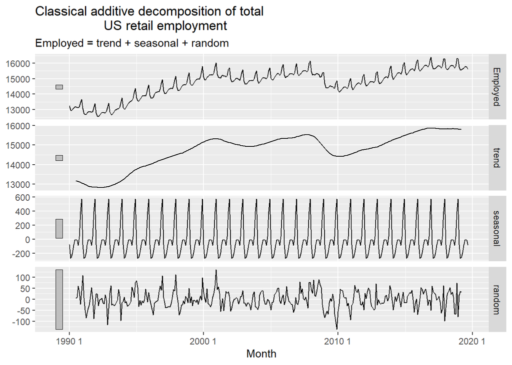

```r
us_retail_employment <- us_employment |>
  filter(year(Month) >= 1990, Title == "Retail Trade") |>
  select(-Series_ID)

us_retail_employment |>
  model(
    classical_decomposition(Employed, type = "additive")
  ) |>
  components() |>
  autoplot() +
  labs(title = "Classical additive decomposition of total
                  US retail employment")
```

### Multiplicative decomposition

승법적 시계열 분해(Multiplicative Decomposition)는 **가법적 분해와 유사하지만, 뺄셈 대신 나눗셈을 사용**하는 방식.  
이 방법은 **계절 성분이 데이터의 크기에 비례하여 변화할 때 적절**함.

#### 승법적 분해 단계

##### **1단계: 추세-순환(Trend-Cycle) 성분 계산**

- $m$이 **짝수**이면 **$2 \times m$-MA** 사용
- $m$이 **홀수**이면 **$m$-MA** 사용
- 이를 통해 **추세-순환 성분** $\hat{T_t}$을 추정

##### **2단계: 추세 성분을 제거한 데이터 (Detrended Series) 계산**

$$\frac{y_t}{\hat{T_t}}$$
이를 통해 **추세 성분을 제거하여 계절 변동을 강조**.

##### **3단계: 계절 성분(Seasonal Component) 추정**

- 동일한 계절의 **detrended 값 평균을 계산**하여 계절 성분(계절 지수)을 추정
- **모든 계절 성분의 합이 $m$이 되도록 조정**
- 최종적으로 **추정된 계절 성분**을 $\hat{S_t}$로 설정.

##### **4단계: 잔차(Remainder) 성분 계산**

잔차 성분은 **추정된 계절 및 추세-순환 성분을 나눈 값**으로 계산됨.

$$\hat{R_t} = \frac{y_t}{\hat{T_t} \hat{S_t}}$$

#### 고전적 분해의 한계점

##### ❌ **1. 초반 및 마지막 데이터에서 추세-순환 성분을 추정할 수 없음**

- 예: $m = 12$이면, **처음 6개 및 마지막 6개의 데이터에는 추정값이 없음**
- 따라서, 해당 기간에는 **잔차 성분도 계산할 수 없음**.

##### ❌ **2. 급격한 변동(급등·급락)을 과하게 평활화 (Over-smoothing)**

- 데이터의 **급격한 변화(급등·급락)를 과하게 부드럽게 처리**하는 경향이 있음.

##### ❌ **3. 계절 패턴 변화 반영 불가**

- **고전적 분해는 계절 성분이 해마다 동일하다고 가정**하지만, 현실에서는 계절 패턴이 변할 수 있음.
- 예: **과거에는 겨울철 전력 사용량이 많았으나, 최근에는 여름철 에어컨 사용으로 수요 패턴이 변화**.
- **고전적 방법은 이러한 변화를 반영할 수 없음**.

##### ❌ **4. 이상값(Outliers)에 취약**

- 예: **산업 분쟁 등으로 인해 특정 월의 항공 승객 수가 급감할 경우**,  
  고전적 방법은 이를 적절히 조정하지 못함.
- **더 견고한(robust) 분해 방법이 필요**.

## 3.5 Methods used by official statistics agencies

- 공식 통계 기관(예: 미국 인구조사국, 호주 통계청)은 공식 경제 및 사회 시계열 데이터를 관리하며, 계절 조정을 위해 자체적인 분해 절차를 개발함.
- 대부분 X-11 방법, SEATS 방법, 또는 이 둘을 결합한 방법을 사용함.
- 이러한 방법은 분기별(quarterly) 및 월별(monthly) 데이터에 특화되어 있으며, 일별, 시간별, 주별 데이터의 계절성을 처리하지 못함.
- 최신 구현 방식으로 **“X-13ARIMA-SEATS”**가 사용됨.
- R에서 해당 방법을 사용하려면 seasonal 패키지를 설치해야 함.

### X-11 method

- X-11 방법은 **미국 인구조사국(US Census Bureau)**에서 개발되고, 이후 **캐나다 통계청(Statistics Canada)**에 의해 개선됨.
- 고전적 분해(classical decomposition)를 기반으로 하지만, 단점을 보완하기 위해 여러 추가 기능을 포함.
- 추세-순환(trend-cycle) 추정이 모든 시점(특히 끝부분 포함)에서 가능하며, 계절 성분이 천천히 변화하도록 허용됨.
- 거래일 변동(trading day variation), 공휴일 효과(holiday effects), 예측 변수의 영향 처리 가능.
- 가법적(additive) 및 승법적(multiplicative) 분해 모두 지원.
- 자동화된 과정이며, 이상값(outliers)과 수준 변화(level shifts)에 대해 강건(robust)함.

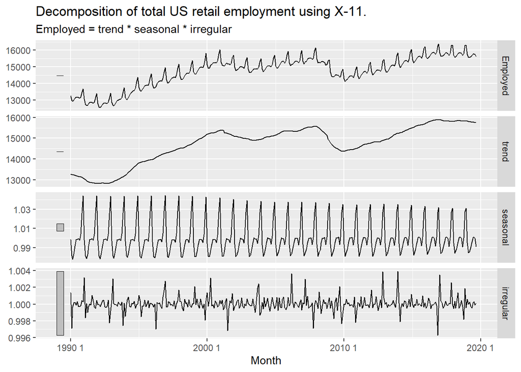

```r
x11_dcmp <- us_retail_employment |>
  model(x11 = X_13ARIMA_SEATS(Employed ~ x11())) |>
  components()
autoplot(x11_dcmp) +
  labs(title =
    "Decomposition of total US retail employment using X-11.")
```

- X-13ARIMA-SEATS는 승법적(multiplicative) 분해를 사용하지만, 이번 사례에서는 STL 및 고전적 분해(가법적)와 큰 차이를 보이지 않음.
- X-11의 추세-순환(trend-cycle) 성분은 2007~2008년 금융 위기의 급락을 더 정확하게 반영함. 반면, STL 및 고전적 분해에서는 위기의 영향이 잔차(remainder) 성분으로 일부 흘러감.
- 1996년의 이상치(outlier)가 X-11의 잔차 성분에서 더 명확하게 드러남.
- 그림 3.15에서 계절 조정된 데이터는 추세-순환 성분과 매우 유사하여 그래프에서 구별하기 어려움.

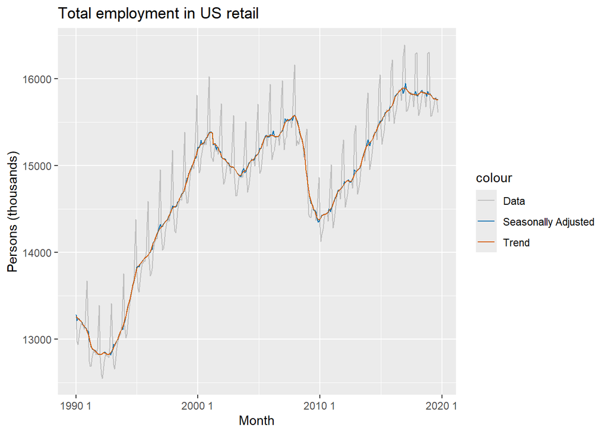

```r
x11_dcmp |>
  ggplot(aes(x = Month)) +
  geom_line(aes(y = Employed, colour = "Data")) +
  geom_line(aes(y = season_adjust,
                colour = "Seasonally Adjusted")) +
  geom_line(aes(y = trend, colour = "Trend")) +
  labs(y = "Persons (thousands)",
       title = "Total employment in US retail") +
  scale_colour_manual(
    values = c("gray", "#0072B2", "#D55E00"),
    breaks = c("Data", "Seasonally Adjusted", "Trend")
  )
```

- 계절 성분의 변화를 시각적으로 분석하기 위해 계절 플롯 및 계절 하위 시리즈 플롯을 활용할 수 있음.
- 그림 3.16은 그림 3.14에서 추출한 계절 성분의 계절 하위 시리즈 플롯을 보여줌.

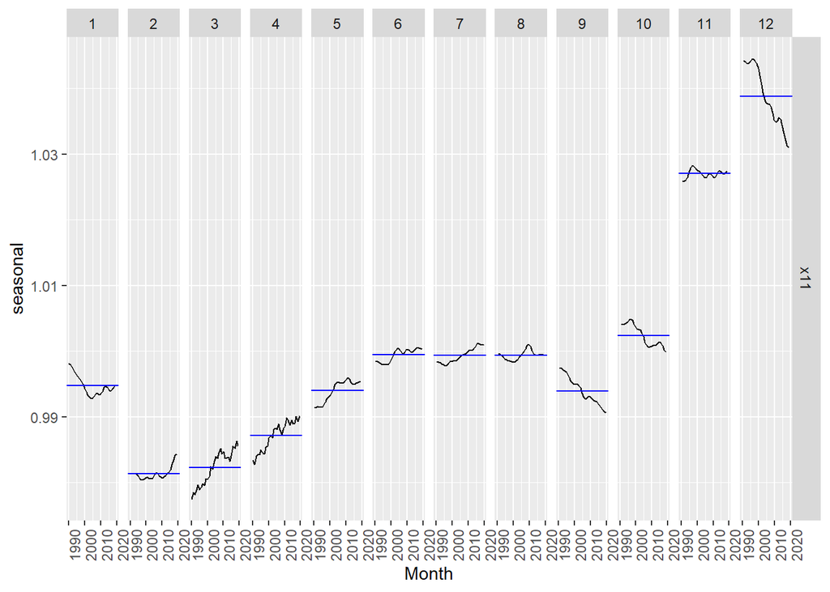

```r
x11_dcmp |>
  gg_subseries(seasonal)
```

### SEATS method

- SEATS는 **“Seasonal Extraction in ARIMA Time Series”**의 약자. *스페인 중앙은행(Bank of Spain)에서 개발되었으며, 현재 전 세계 정부 기관에서 널리 사용됨.
- ARIMA 모델을 기반으로 계절 성분을 추출하는 방법(ARIMA 모델은 9장에서 다룸).

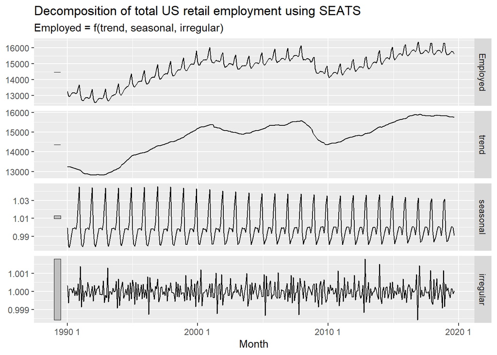

```r
seats_dcmp <- us_retail_employment |>
  model(seats = X_13ARIMA_SEATS(Employed ~ seats())) |>
  components()
autoplot(seats_dcmp) +
  labs(title =
    "Decomposition of total US retail employment using SEATS")
```

- 그림 3.17: SEATS 방법을 미국 소매업 종사자 수 데이터에 적용한 결과.
- SEATS와 X-11(X-13ARIMA-SEATS)의 결과가 매우 유사함.
- X_13ARIMA_SEATS() 함수는 seasonal 패키지를 호출하며, X-11 및 SEATS 방법의 다양한 옵션을 제공.

## 3.6 STL decomposition

**STL (Seasonal and Trend decomposition using Loess)**은 **Loess 기법을 활용한 시계열 분해 방법**으로, **비선형 관계를 추정**하는 데 사용됨.

- **1990년 R. B. Cleveland 등**이 개발
- **2022년 Bandara 등**이 다중 계절성(multiple seasonal patterns) 처리 기능 추가

#### 1. STL의 장점

STL 분해는 **고전적 분해(Classical Decomposition)** 및 **SEATS, X-11 방법**보다 다음과 같은 **강점**이 있습니다.

##### ✅ 1. 모든 유형의 계절성 처리 가능

- **SEATS 및 X-11은 월별/분기별 데이터만 처리 가능하지만**, STL은 **일별, 시간별 데이터도 처리 가능**.

##### ✅ 2. 계절 성분 변화 허용 & 조정 가능

- 계절 성분이 시간이 지나면서 변할 수 있으며,  
  **사용자가 변화 속도를 직접 조정 가능**.

##### ✅ 3. 추세-순환(Trend-Cycle)의 부드러움 조정 가능

- 사용자가 **추세 성분의 변화 속도를 직접 설정 가능**하여 유연한 분석이 가능.

##### ✅ 4. 이상값(Outliers)에 강건한 분석 가능

- **이상값이 추세 및 계절 성분에 영향을 미치지 않도록 설정 가능**.
- **그러나 이상값은 잔차(Remainder) 성분에 반영됨**.

#### 2. STL의 단점

##### ❌ 1. 거래일(Trading Day) 달력 효과(Calendar Variation) 자동 처리 불가

- SEATS 및 X-11은 거래일 효과를 자동 조정하지만, **STL은 이를 자동으로 처리하지 않음**.

##### ❌ 2. 기본적으로 가법적(Additive) 분해만 제공

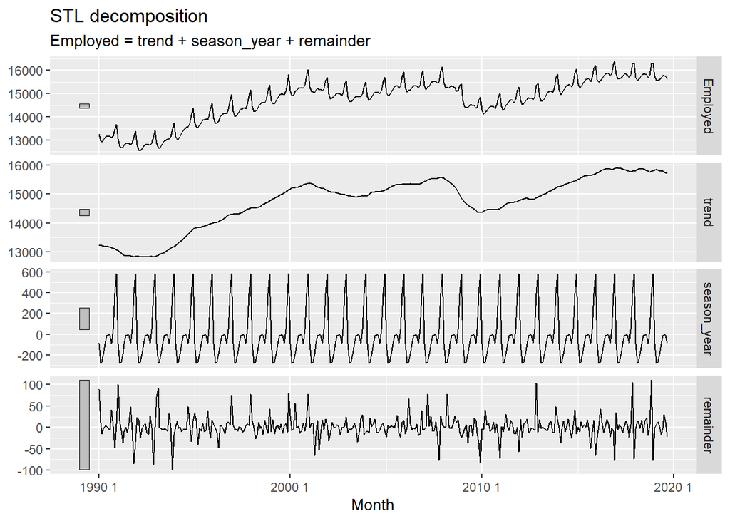

```r
us_retail_employment |>
  model(
    STL(Employed ~ trend(window = 7) +
                   season(window = "periodic"),
    robust = TRUE)) |>
  components() |>
  autoplot()
```

#### 1. STL의 주요 매개변수

STL을 사용할 때 **두 가지 주요 매개변수**가 있습니다.

##### ✅ 1. 추세-순환 윈도우 (`trend(window = ?)`)

- **추세-순환 성분이 얼마나 빠르게 변할 수 있는지를 조절**
- **작은 값 → 빠른 변화 반영**, **큰 값 → 더 부드러운 추세**
- **홀수 값을 사용해야 함**

##### ✅ 2. 계절 윈도우 (`season(window = ?)`)

- **계절 성분이 얼마나 빠르게 변할 수 있는지를 조절**
- **작은 값 → 빠른 계절 변화 반영**, **큰 값 → 장기적 계절 변화 반영**
- **홀수 값을 사용해야 함**
- **무한대로 설정(`season(window='periodic')`)하면, 계절 패턴이 해마다 동일하도록 강제됨**

#### 2. STL의 기본 설정

- `STL()` 함수는 **기본적으로 자동 STL 분해를 수행**
- **단일 계절 주기(Single Seasonal Period)**
  - `season(window=11)` (기본 설정)
  - **추세 윈도우는 계절 주기에 따라 자동 선택됨**
  - **월별 데이터의 경우 → `trend(window=21)` 기본값**
- **다중 계절 주기(Multiple Seasonal Periods)**
  - 기본 계절 윈도우 값: `11, 15, 19, …`
  - **큰 윈도우 값일수록 계절 변화를 더 천천히 반영**
  - **과적합(Overfitting) 방지 및 점진적인 변화 반영**

그러나 **모든 시계열에 적합한 것은 아니므로, 필요에 따라 조정해야 함**.